# TP02 - Preprocesamiento

Nicolas Cavasin

1/10/2020

## Limpieza de datos

### 1. Datos faltantes:

Se cuenta con el dataset *encuesta_universitaria.csv*, el cual posee valores faltantes para la variable `tiempo_traslado`. Aplique los siguientes métodos a efectos de reemplazar esos valores:

1. Verifique cual es la proporción de valores faltantes respecto a la cantidad total de instancias del dataset.

```
## [1] "Los datos faltantes representan el 15% (14.65) del dataset."
```

```
## [1] "Eso equivale a 863 tuplas sobre las 5891 totales"
```

2. Genere un nuevo atributo utilizando solo los registros con valores observados para el atributo.

```
## [1] "El nuevo atributo ha sido creado."
```

3. Genere un nuevo atributo en el que sustituya los valores faltantes por la media encontrada para el atributo.

```
## [1] "Cantidad de valores a imputar por la media (48.28): 863"
```

```
## [1] "Cantidad de valores a imputar por la media (48.28): 0"
```

4. Genere un nuevo atributo en el que sustituya los valores faltantes de acuerdo al método de “hot deck imputation”.

```
## [1] "Cantidad de valores a imputar por hot deck: 863"
```

```
## [1] "Cantidad de valores a imputar por hot deck: 0"
```

5. Analice los resultados encontrados a partir de la aplicación de los métodos anteriores. Compare los mismos realizando gráficos sobre los valores resultantes en cada caso.

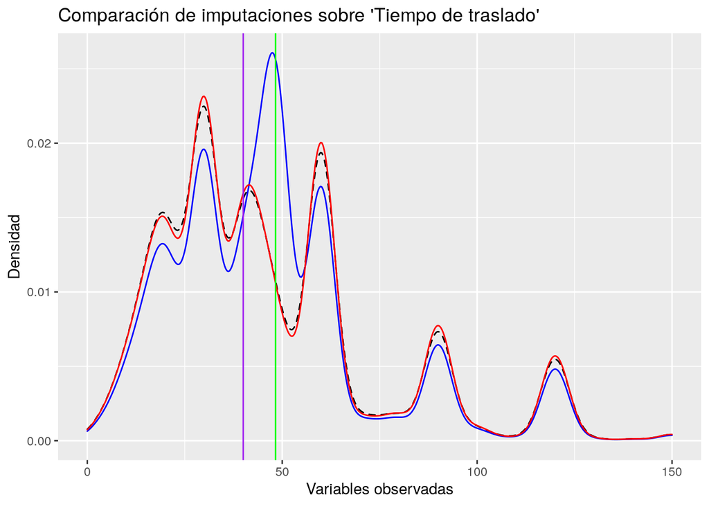

### 2. Manejo de ruido:

Para el dataset anterior, avance sobre las siguientes operaciones para los atributos numéricos (cuantitativos continuos):

1. Verifique en primer lugar la distribución de los datos, utilice algún método gráfico para esto.

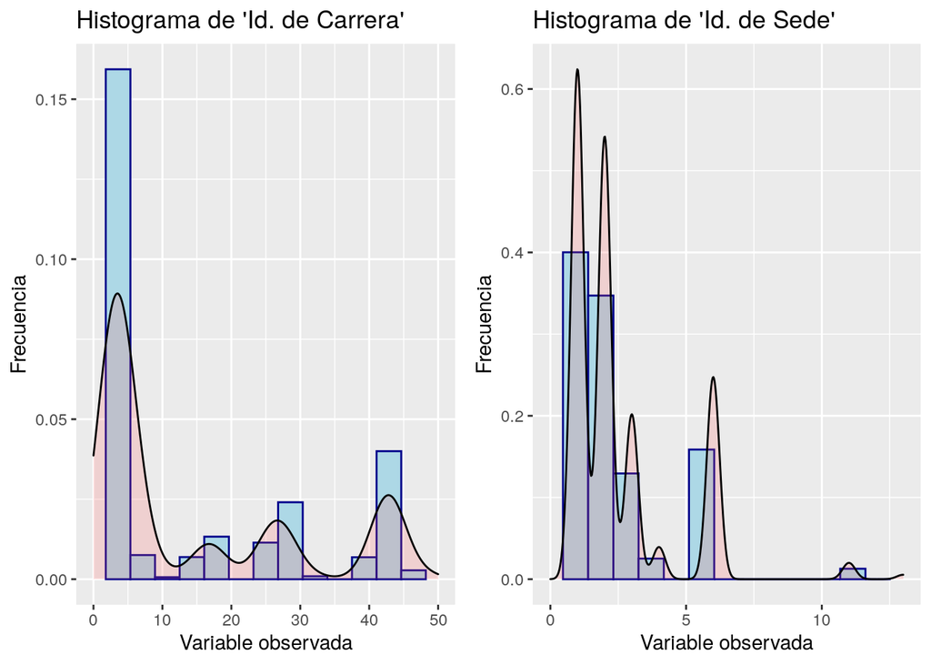

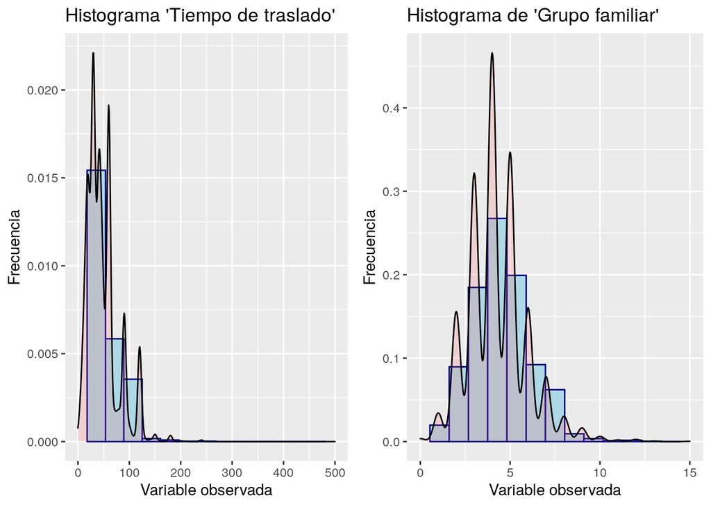

2. Realice un suavizado utilizando *binning* por *frecuencias iguales* (con 5 bins) y estime el valor del bin por el cálculo de medias.

```
## [1] "Se ha completado el suavizado por igual frecuencia de 'Carrera'."
```

```
## [1] "Se ha completado el suavizado por igual frecuencia de 'Sede'."
```

```
## [1] "Se ha completado el suavizado por igual frecuencia de 'Tiempo de traslado'."
```

```
## [1] "Se ha completado el suavizado por igual frecuencia de 'Grupo familiar'."
```

3. Ahora, realice el suavizado por *anchos iguales* (con 5 bins) y compare los resultados gráficamente.

```
## [1] "Se ha completado el suavizado por igual ancho de 'Carrera'."
```

```
## [1] "Se ha completado el suavizado por igual ancho de 'Sede'."
```

```
## [1] "Se ha completado el suavizado por igual ancho de 'Tiempo de traslado'."
```

```
## [1] "Se ha completado el suavizado por igual ancho de 'Grupo familiar'."
```

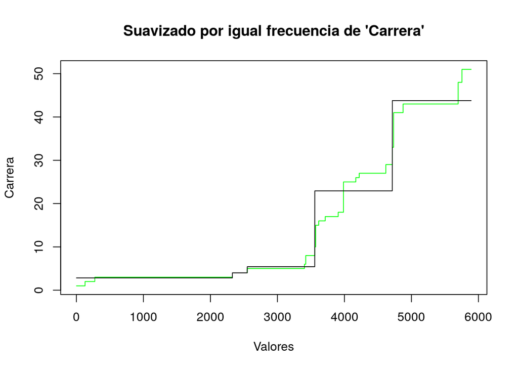

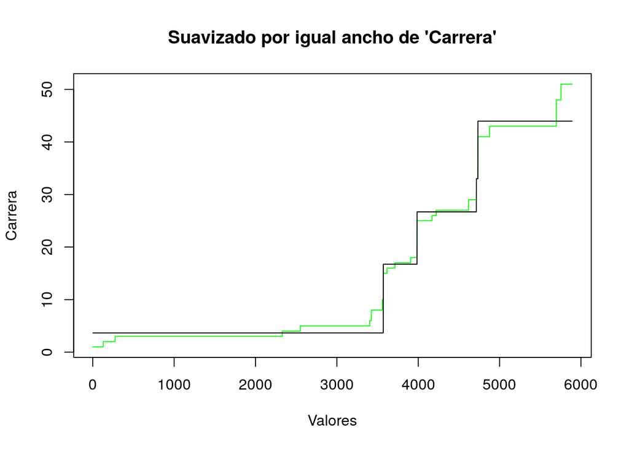

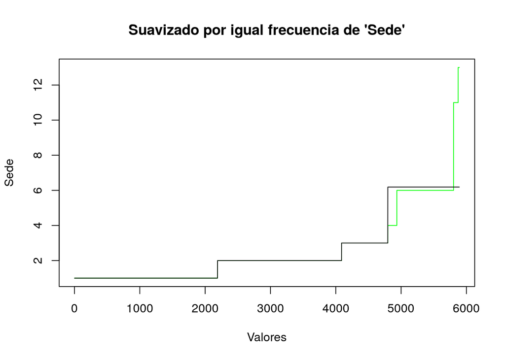

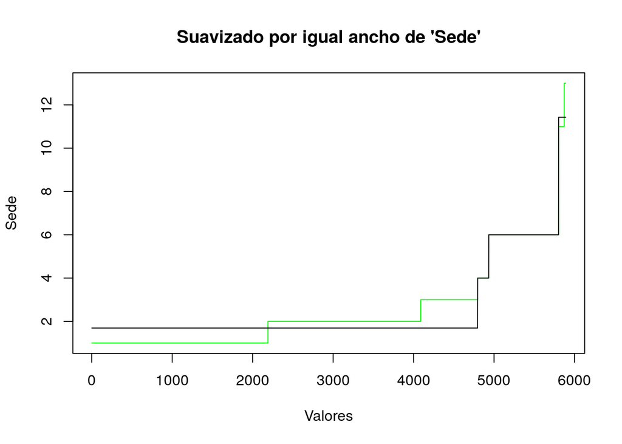

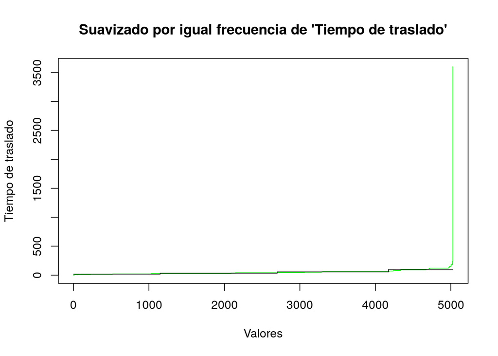

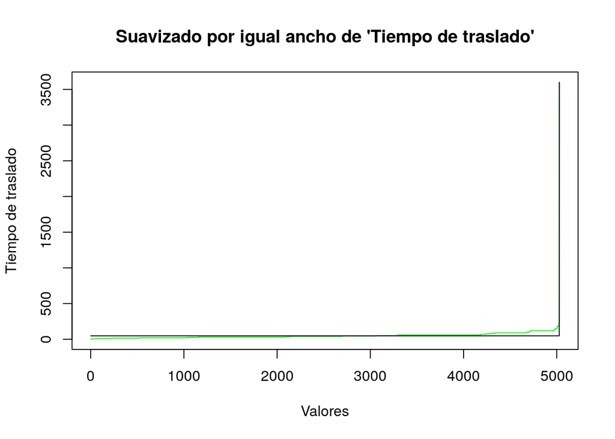

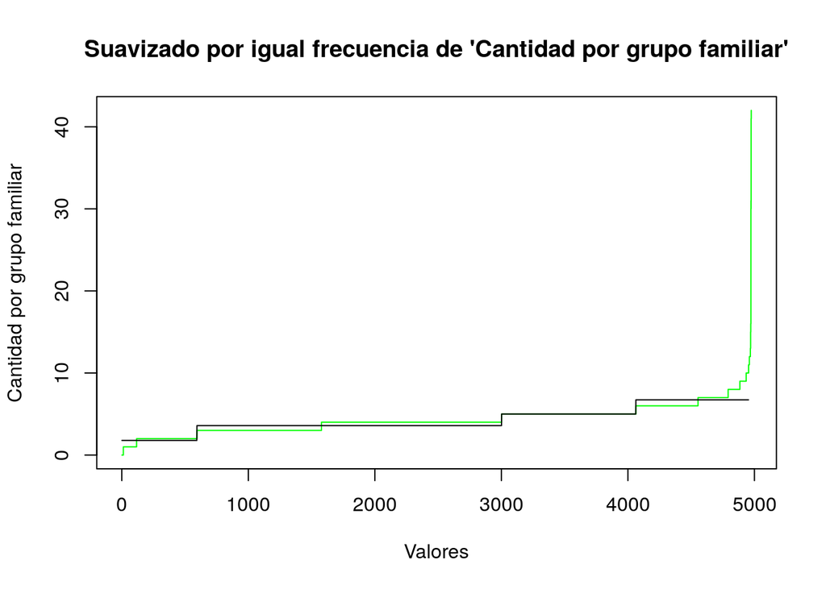

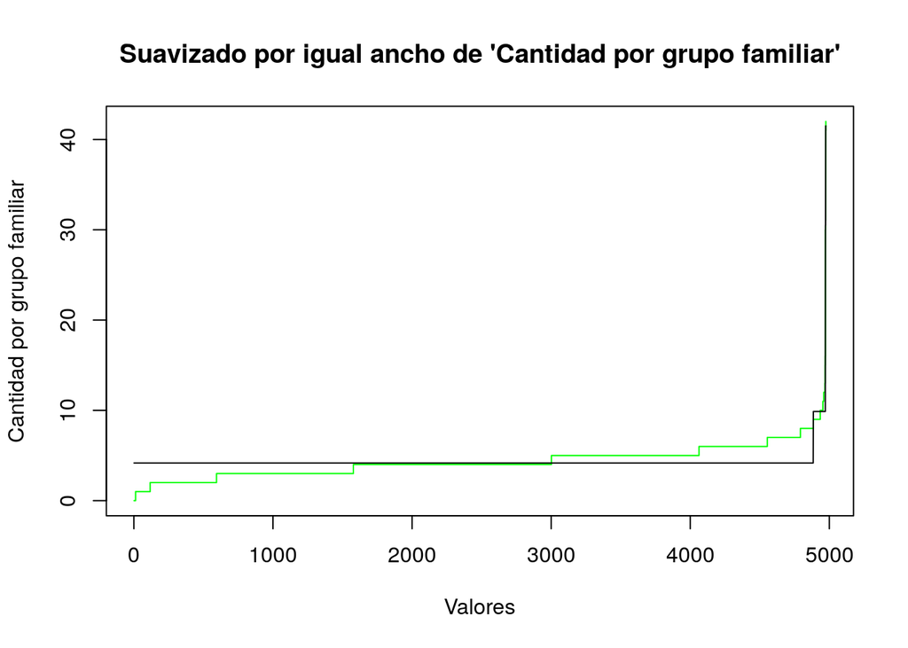

### 3. Detección de outliers:

Ahora, trabaje sobre el mismo atributo del dataset original con las siguientes consignas:

1. Verifique la existencia de *outliers* en el atributo `tiempo_traslado` en función del resto de los atributos. ¿En todos los casos se trata de un valor anómalo?

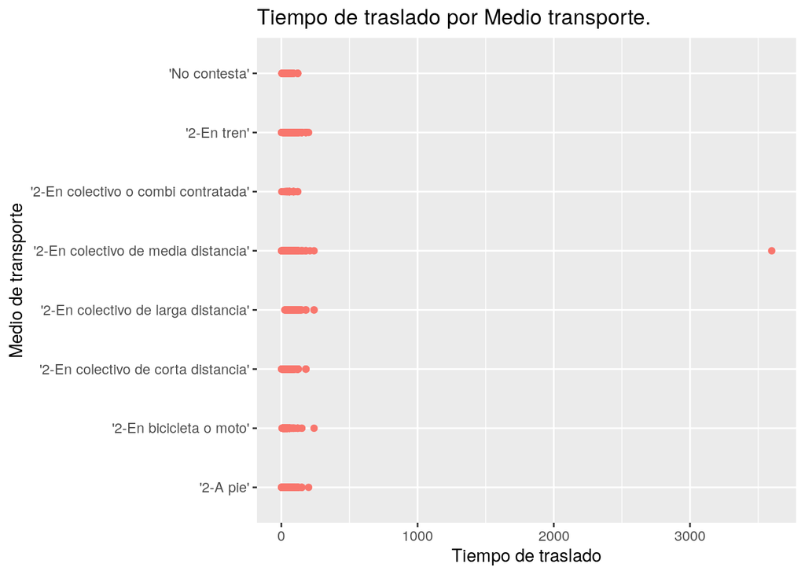

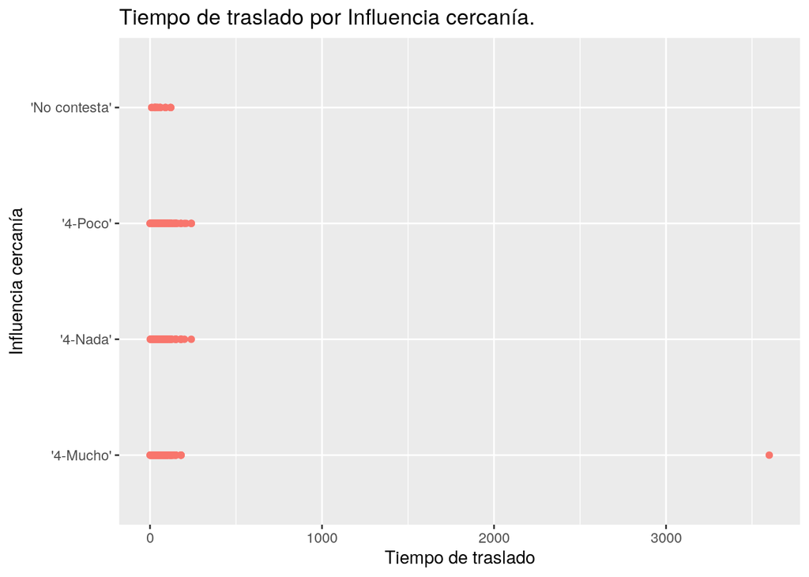

- Debido a que la variable en observación es *Tiempo de traslado* se decidió graficar las columnas que podrían estar relacionadas con la existencia de outliers en la misma.
- Como se puede observar, la existencia del outlier coincide con el valor *Colectivo de media distancia* de la columna *Medios de transporte* así como también con el valor *Mucho* de la columna *Influencia por cercanía*.
2. Aplique las técnicas de análisis y detección vistas en clase: IRQ, SD (seleccione el N que mejor se adapte a su criterio) y Z-Score (seleccione el umbral que mejor se adapte a su criterio).

```
## [1] "Antes de comenzar a aplicar las técnicas sugeridas, se mostarán las medidas de posición y dispersión para tener una orientación mínima del comportamiento de este atributo en su estado original."
```

```
## [1] "Media 48.28."
```

```
## [1] "Mediana 40.00."
```

```
## [1] "Moda 30.00."
```

```
## [1] "Desviación estándar 58.49."
```

```
## [1] "Varianza 3420.86."
```

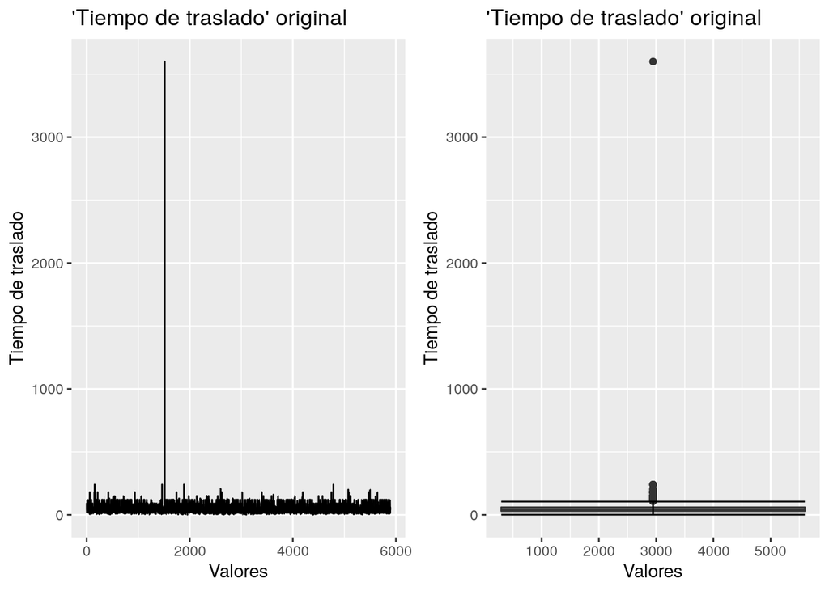

*Técnica por IRQ*

```
## [1] "El IRQ de 'Tiempo de traslado' es 30."
```

```
## [1] "La barrera mínima, aplicando IRQ, está ubicada en -15."
```

```
## [1] "La barrera máxima, aplicando IRQ, está ubicada en 105."
```

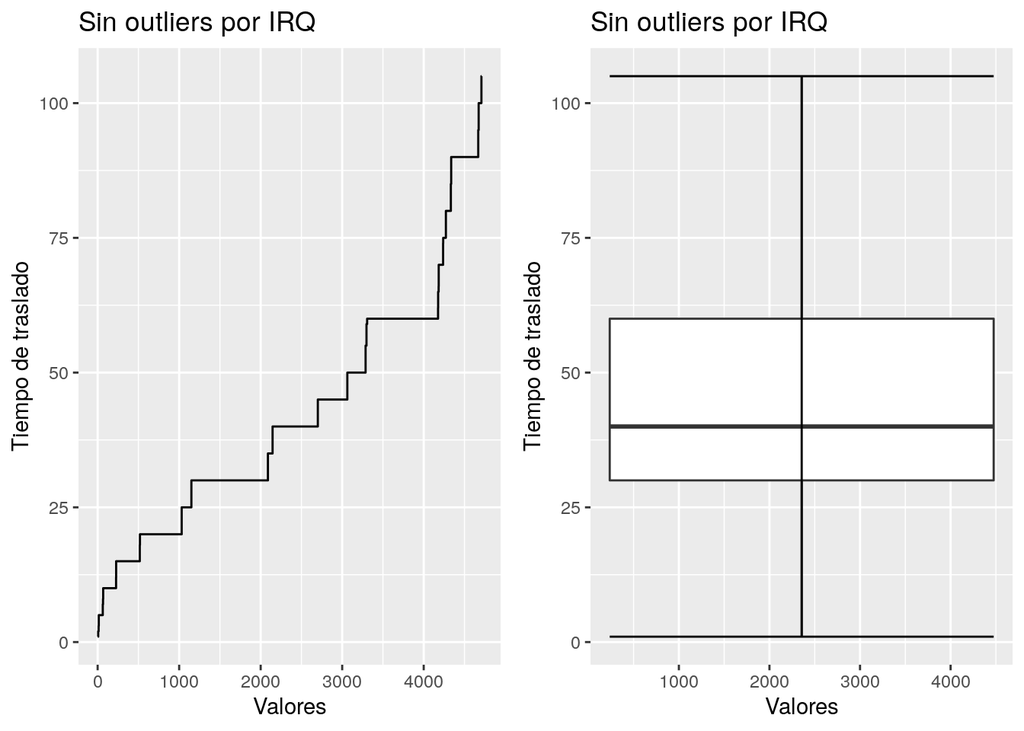

*Observaciones:*

- Es interesante que luego de aplicar la técnia por IRQ sobre la variable no hayan quedado outliers *válidos* o *no-ruidosos*.
- Esto se puede apreciar claramente en el boxplot de la derecha.
- Dado que el atributo en cuestión posee una gran dispersión, se esperaba que haya algún valor cercano a las barreras mínimas y máximas, pero que esté por fuera, y cuente como un outlier “*válido*”.

*Técnica por Desviación Estándar*

```
## [1] "[Criterio de desviaciones (N) = 2]"
```

```
## [1] "La SD de 'Tiempo de traslado' es 58.49."
```

```
## [1] "La barrera mínima, aplicando SD, está ubicada en -68.69."
```

```
## [1] "La barrera máxima, aplicando SD, está ubicada en 165.26."
```

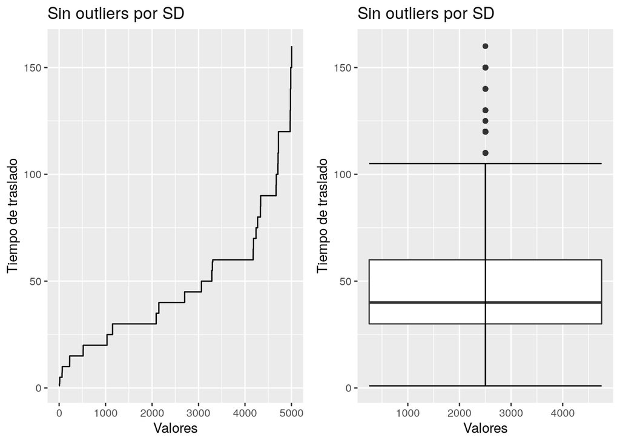

*Observaciones:*

- Utilizando la eliminación de outliers por Desviación Estándar, y a diferencia de la anterior, sí podemos observar la aparición de los outliers “*válidos*”.
- Esto probablemente se deba a que el N = 2. Es decir, los valores considerados *ruidosos* son los que se encuentran por encima de +N SDs o -N SDs de la media. Como este atributo es muy disperso, es normal que haya valores a mayor o menor distancia que N SDs.
- Por lo tanto, se entiende que la aparición de estos nuevos outliers es por haber establecido que N = 2. Si hubiese elegido N = 3 tal vez se repetiría lo mismo que con la técnica por IRQ.
- Nuevamente, el boxplot es muy útil para visualizar esto.

*Técnica por Z-Score*

```
## [1] "[Criterio de umbral = 2]"
```

```
## [1] "Se ha calculado el Z-Score de 'Tiempo de traslado'."
```

```
## [1] "Se han seleccionado los valores que se encuentran dentro del umbral (-2; 2)."
```

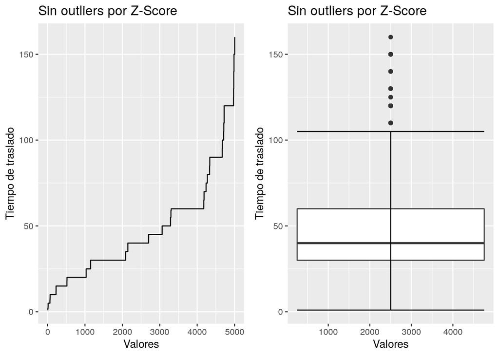

*Observaciones:*

*Nota:* las conclusiones fueron puestas al pie de cada gráfico para facilitar el análisis.

## Reduccion de dimensionalidad

### 4. A partir del dataset *auto-mpg.data-original.txt*, se solicita trabajar sobre las siguientes consignas:

1. Evalúe la relación entre atributos a partir del coeficiente de correlación de Pearson y un análisis gráfico de *heatmap* para estudiar la posibilidad de eliminar redundancia en el dataset. En caso de corresponder, aplique las técnicas de Reducing Highly Correlated Columns trabajadas en clase.

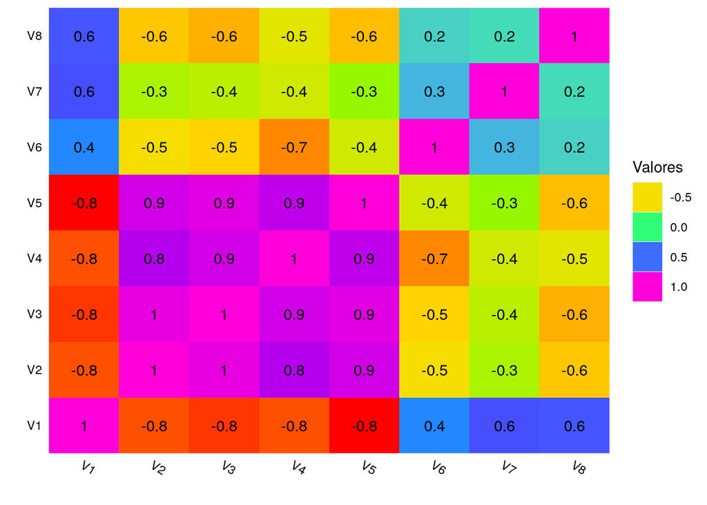

- El heatmap se creó a partir de los resultados arrojados por la función `cor()`, quién calcula el coeficiente de Pearson y determina qué tan relacionadas están dos variables.
- A simple vista, solo por agrupamiento de colores, se observa que el heatmap posee una *sub-matriz* altamente relacionada (positiva y negativamente) entre las variables `V1`-`V5`, ubicada en la esquina inferior izquierda
- Sobre esta *sub-matriz* altamente relacionada se observa que:
  1. La variable `V1` está muy relacionada *negativamente* con las variables `V2`, `V3`, `V4` y `V5`.
  2. La variable `V2` está muy relacionada *positivamente* con las variables `V3`, `V4` y `V5`.
  3. Por último, se repite la relación *positiva* entre `V3`, `V4` y `V5`.
- Respecto el resto del heatmap, podemos decir que:
  1. Las variables `V2` y `V5` casi no tienen relación con la variable `V7`.
  2. Las duplas de variables (`V6`;`V7`), (`V6`;`V8`) y (`V7`;`V8`) son las menos relacionadas de todo el dataset.
- Para confirmar lo observado, se utilizó la función `findCorrelation()` -perteneciente a la librería `caret`- que se encargó de buscar los atributos con una correlación igual o mayor al parámetro que deseemos, en este caso 0.75.

```
## [1] "V3" "V4" "V2" "V5"
```

### 5. Análisis de componentes principales:

Cargue en R el dataset *europa.dat* y conteste las siguientes consignas a través de las funcionalidades provistas por esa herramienta:

1. Calcule la matriz de covarianzas. ¿Qué nos indica la misma sobre los atributos del dataset?

```
##        Agr   Min    Fab   Ene   Con     IS   Fin    SSP    TC
## Agr 153.30  1.71 -36.69 -0.77 -3.26 -38.58 -4.00 -65.82 -5.82
## Min   1.71  0.97   2.69  0.13 -0.17  -2.02 -1.33  -2.13  0.14
## Fab -36.69  2.69  35.33  0.39  1.50   0.38 -5.59   0.96  0.79
## Ene  -0.77  0.13   0.39  0.12 -0.15   0.09  0.02   0.07  0.09
## Con  -3.26 -0.17   1.50 -0.15  1.57   0.99 -0.60  -0.04  0.15
## IS  -38.58 -2.02   0.38  0.09  0.99  19.20  3.91  15.89  0.12
## Fin  -4.00 -1.33  -5.59  0.02 -0.60   3.91  7.84   1.13 -1.42
## SSP -65.82 -2.13   0.96  0.07 -0.04  15.89  1.13  45.73  4.44
## TC   -5.82  0.14   0.79  0.09  0.15   0.12 -1.42   4.44  1.53
```

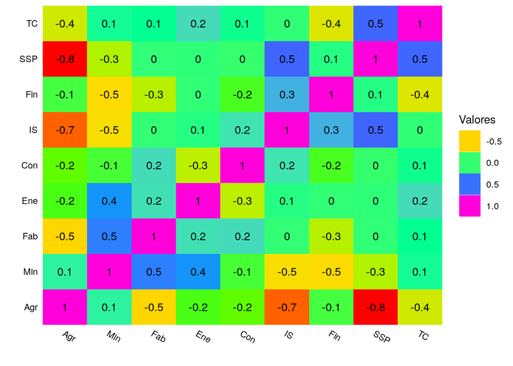

2. Realice ahora el análisis de componentes principales. ¿Cuánto explica de la variación total del dataset la primera componente? ¿Y si se incorpora la segunda? ¿Y el primer auto-valor?

```
## Importance of components:
##                           Comp.1    Comp.2    Comp.3    Comp.4     Comp.5
## Standard deviation     1.6342607 1.4673455 1.1765473 1.0460817 0.73977719
## Proportion of Variance 0.3091213 0.2492017 0.1602157 0.1266536 0.06334147
## Cumulative Proportion  0.3091213 0.5583230 0.7185387 0.8451923 0.90853375
##                            Comp.6     Comp.7     Comp.8       Comp.9
## Standard deviation     0.61934045 0.49662406 0.39999969 7.111610e-03
## Proportion of Variance 0.04439613 0.02854577 0.01851849 5.853587e-06
## Cumulative Proportion  0.95292989 0.98147566 0.99999415 1.000000e+00
```

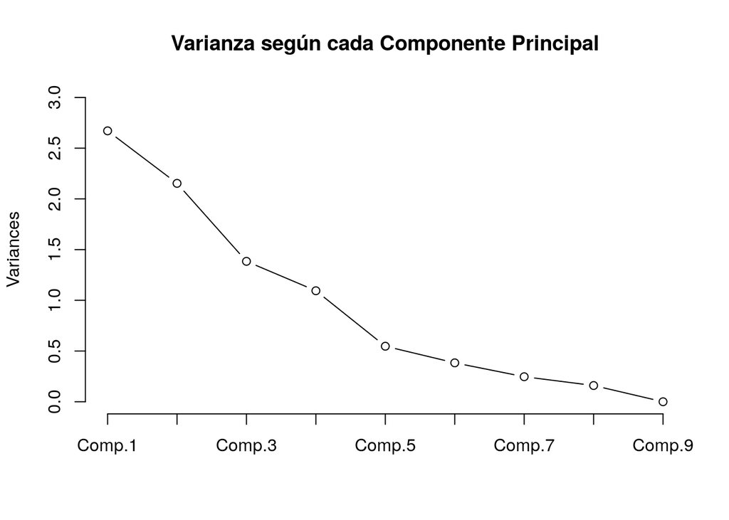

4. Analice la matriz de loadings. ¿Qué información provee? ¿Qué variables están más correlacionadas con la primera componente?

```
##
## Loadings:
##     Comp.1 Comp.2 Comp.3 Comp.4 Comp.5 Comp.6 Comp.7 Comp.8 Comp.9
## Agr  0.560  0.163         0.208  0.139  0.113                0.760
## Min  0.252 -0.523 -0.132 -0.154               -0.771  0.152
## Fab -0.117 -0.468  0.124 -0.532 -0.340 -0.176  0.423         0.368
## Ene        -0.298 -0.618 -0.115  0.584         0.239 -0.333
## Con -0.141         0.678 -0.206  0.594 -0.198 -0.150 -0.239
## IS  -0.487  0.180        -0.235  0.179  0.606 -0.143  0.424  0.270
## Fin -0.115  0.476 -0.337 -0.282        -0.672 -0.172  0.221  0.173
## SSP -0.521                0.320 -0.286        -0.262 -0.542  0.411
## TC  -0.257 -0.360         0.597  0.224 -0.299  0.148  0.527
##
##                Comp.1 Comp.2 Comp.3 Comp.4 Comp.5 Comp.6 Comp.7 Comp.8 Comp.9
## SS loadings     1.000  1.000  1.000  1.000  1.000  1.000  1.000  1.000  1.000
## Proportion Var  0.111  0.111  0.111  0.111  0.111  0.111  0.111  0.111  0.111
## Cumulative Var  0.111  0.222  0.333  0.444  0.556  0.667  0.778  0.889  1.000
```

- La matriz de loadings muestra a qué variable está más asociada cada Componente Principal.
- En el caso de la primera componente, la variable más asociada de manera directa es `Agr` con el %56, mientras que la mas asociada de manera indirecta es `SSP` con un %52.1.
5. Genere un gráfico de biplot y explique brevemente que información le provee el mismo.

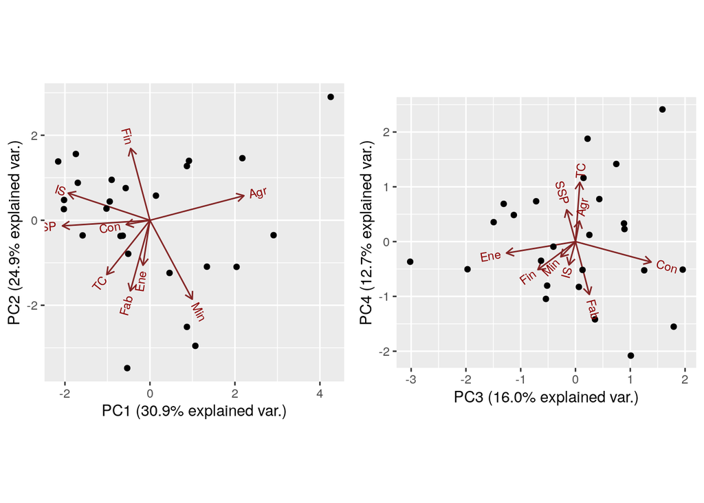

- Los gráficos biplot permite ver en dos dimensiones el comportamiento de las dos Componentes Principales seleccionados.
- Muestran todos los valores que se corresponden con las observaciones para dichas CPs.
6. En función de los análisis realizados en los puntos anteriores. ¿Cuántas componentes principales elegiría para explicar el comportamiento del dataset? Justifique esa cantidad.
- La cantidad de *Componentes Principales* a elegir es definido por la cantidad de varianza que estos acumulan, y por lo general se requiere una acumulación de ~80% o más. En el caso de este dataset se necesitan los primeros 4 *Componentes Principales* ya que acumulan el 84.51% de la varianza total

## Transformación de datos

### 6. Discretización:

A partir del dataset *encuesta_universitaria.csv*, opere sobre el atributo `tiempo_traslado` de la siguiente manera:

1. Transforme el atributo a discreto, definiendo 5 rangos de acuerdo al análisis de frecuencia de los valores encontrados para el atributo.

```
## [1] "Se ha discretizado el atributo en 5 bins de igual frecuencia."
```

```
## [1] "Se ha calculado la media de cada bin."
```

2. Transforme el atributo a discreto, definiendo 5 rangos de acuerdo al método de anchos iguales.

```
## [1] "Se ha discretizado el atributo en 5 bins de igual ancho."
```

```
## [1] "Se ha calculado la media de cada bin."
```

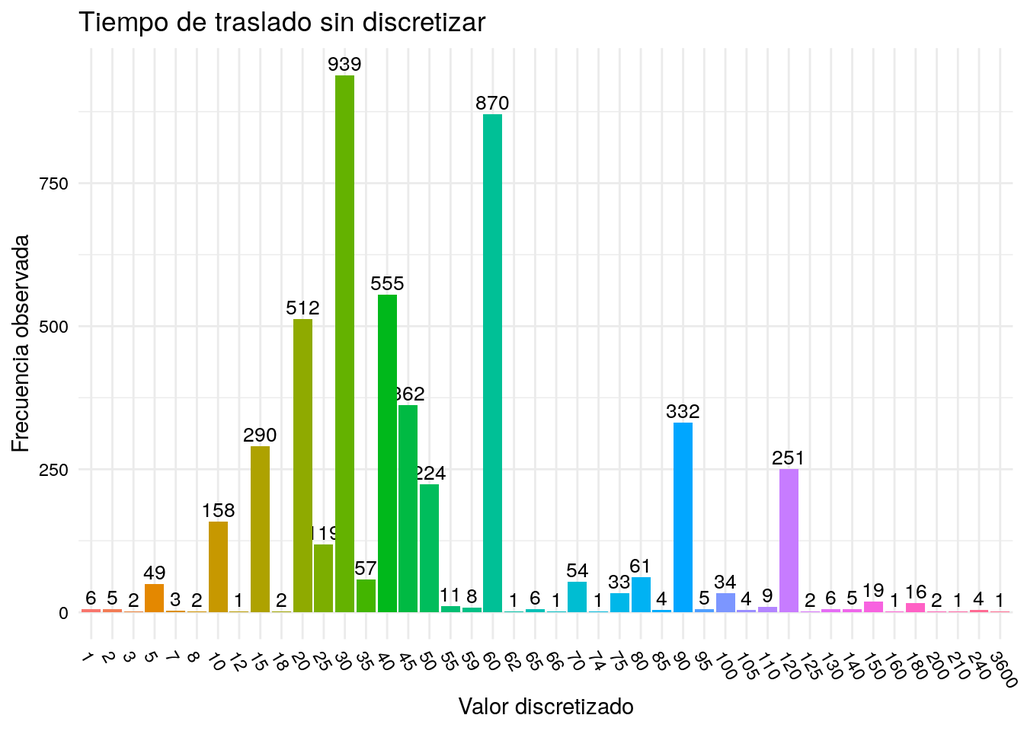

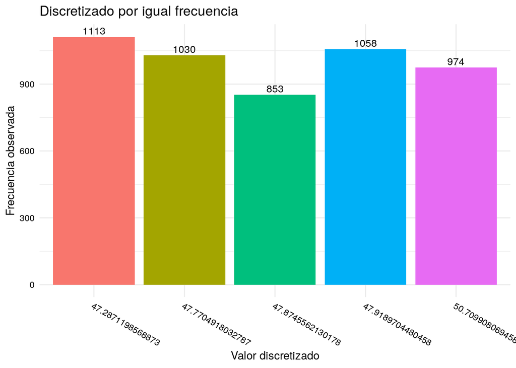

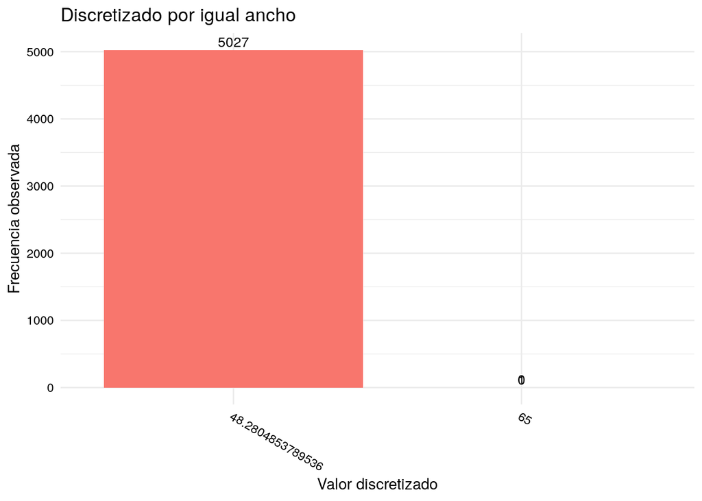

- Conclusiones:
  1. La discretización por igual ancho no funcionó y no sé porqué.
  2. La discretización por igual frecuencia dió una distribución deprimida hacia su centro, muy extraño.

### 7. Normalización:

A partir del dataset *encuesta_universitaria.csv*, opere sobre el atributo `tiempo_traslado` de la siguiente manera:

1. Normalice el atributo utilizando la técnica de mínimo-máximo.

```
## [1] "Máximo = 61. Mínimo = -1"
```

```
## [1] "Rango = 62."
```

```
## [1] "Ha finalizado la normalización por la técnica Mínimo-Máximo."
```

2. Ahora, normalice el atributo mediante la técnica de Z-Score propuesta en el libro *Data Mining. Concepts & Techniques* de Jiawei Han & otros.

```
## [1] "Media = -0.00."
```

```
## [1] "Desviación estándar = 1.00."
```

```
## [1] "Ha finalizado la normalización mediante Z-Score."
```

3. Por último, utilice la técnica de escalado decimal para llevar adelante la tarea de normalización.

```
## [1] "Mayor: 3600"
## [1] "Exponente: 4"
## [1] "Factor de escala: 10000"
```

```
## [1] "Ha finalizado la normalización mediante Decimal Scaling."
```

4. Analice los resultados encontrados. Compare los mismos realizando gráficos sobre los atributos resultantes en cada caso.

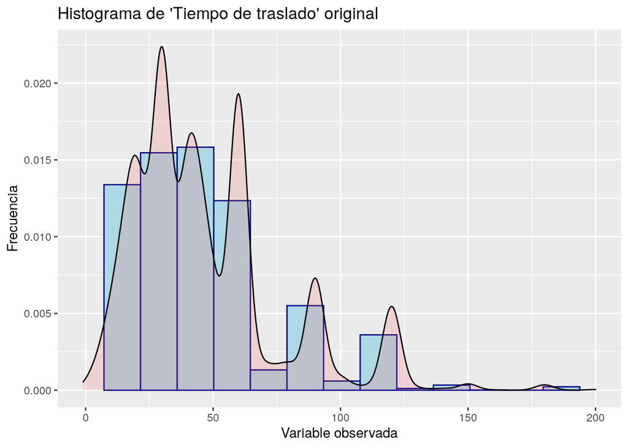

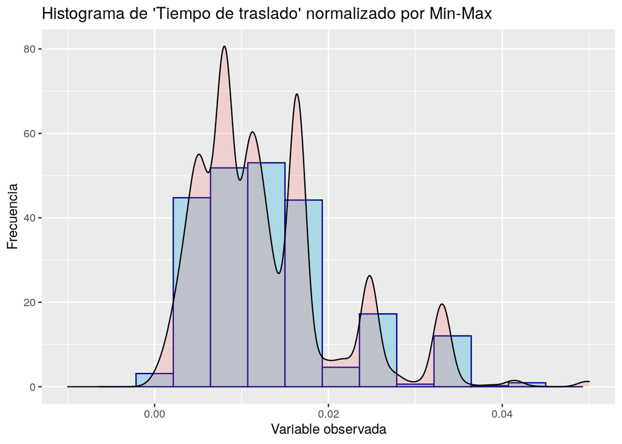

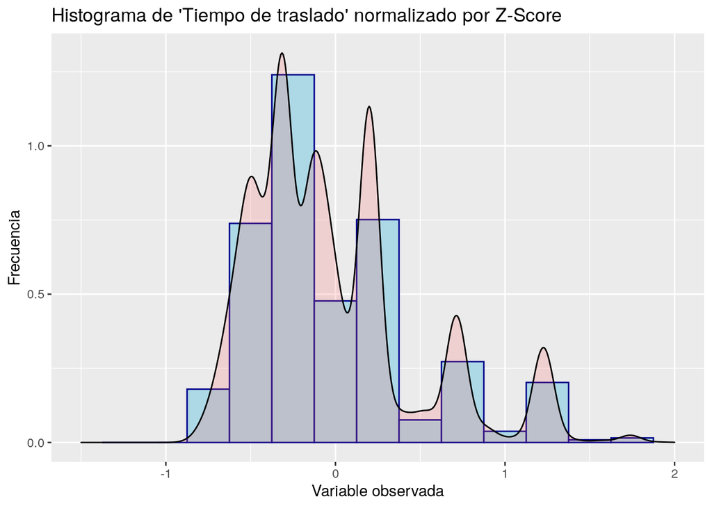

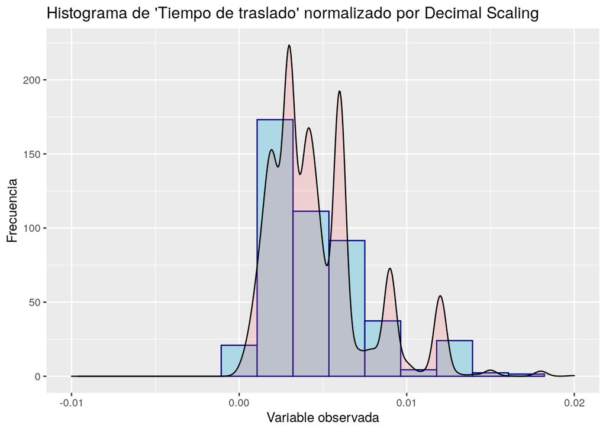

#### Fuentes:

[Decscaling](https://www.rdocumentation.org/packages/dprep/versions/3.0.2/topics/decscale), [Boxplots](https://www.r-graph-gallery.com/265-grouped-boxplot-with-ggplot2.html), [Histogramas](http://www.sthda.com/english/wiki/ggplot2-histogram-plot-quick-start-guide-r-software-and-data-visualization), [Densidades](https://www.r-graph-gallery.com/135-stacked-density-graph.html), [Heatmaps 1](https://rpubs.com/htejero/212365), [Heatmaps 2](https://learnr.wordpress.com/2010/01/26/ggplot2-quick-heatmap-plotting/), [Biploting](https://github.com/vqv/ggbiplot), [Agrupado de plots](https://stackoverflow.com/questions/1249548/side-by-side-plots-with-ggplot2).